# Integrate analysis of pancreas islet scRNA-seq dataset

Weixu Wang

In this tutorial, I will demonstrate ICAnet’s ability to integrate scRNA-seq dataset from different sequence platform. We also want to show that using our SVD based cell embedding could improve the batch mixing. Meanwhile, I also want to show that how to visualize the statistical significant modules into binary heatmap. Here, I will introduce two different workflow to integrate different batches.

### Stage I: Preprocessing, Normalization, and Scaling

This tutorial is for users who need to integrate more than three batches with multiple cell types. To deal with this, ICAnet need to perform preprocessing(denoise) on each dataset. Here, I used three pancreas islet single cell datasets produced by different lab (named as baron et al, muraro et al, and segerostople et al) to illustrate how ICAnet perform batch effects correction on these dataset. First, loading the datasets, all datasets can be download from https://hemberg-lab.github.io/scRNA.seq.datasets/

```r
setwd("/mnt/data4/weixu/MCTA/immuneAtlas/Pancreas")
source("ICAnet_functions.R")
library(Seurat)
library(cowplot)
library(SingleCellExperiment)
baron <- readRDS("baron-human.rds")
muraro <- readRDS("muraro.rds")
segerstolpe <- readRDS("segerstolpe.rds")
baron_exp <- counts(baron)
segerstolpe_exp <- counts(segerstolpe)
muraro_exp <- normcounts(muraro)
geneID <- rownames(muraro_exp)
geneID_str <- strsplit(geneID,split="_")
for(i in 1:length(geneID)){
  geneID[i] <- geneID_str[[i]][1]
}
rownames(muraro_exp) <- geneID
geneID <- c(rownames(baron_exp),rownames(muraro_exp),rownames(segerstolpe_exp))
geneID <- names(table(geneID))[table(geneID)==3]
baron_exp <- baron_exp[geneID,]
segerstolpe_exp <- segerstolpe_exp[geneID,]
muraro_exp <- muraro_exp[geneID,]
```

Further, we define the *batch* variable and *cell type* variable, and create seurat object

```r
batch <- c(baron$human, rep("segerstolpe",(ncol(segerstolpe_exp))),rep("muraro",ncol(muraro_exp)))
celltype <- c(as.character(as.matrix(baron$cell_type1)),
              as.character(as.matrix(segerstolpe$cell_type1)),
              as.character(as.matrix(muraro$cell_type1)))
pancreas <- CreateSeuratObject(cbind(baron_exp,segerstolpe_exp,muraro_exp))
pancreas$batch <- batch
pancreas$celltype <- celltype
```

Then, like Seurat V3(CCA) preprocessing, we perform normalization on each dataset and select highly variable gene for each batch to merge these datasets. For the reason that there has some researches point out that highly variable gene selection improves the performance of data integration methods[1]

```r
pancreas.list <- SplitObject(pancreas, split.by="batch")
for(i in 1:length(pancreas.list)) {
   pancreas.list[[i]] <- NormalizeData(pancreas.list[[i]],verbose=FALSE)
   pancreas.list[[i]] <- FindVariableFeatures(pancreas.list[[i]],selection.method="vst",nfeature=8000,verbose=FALSE)
}
```

** Feature selection for integrated analysis of multiple datasets ** The users could use different way to select variable feaures 1): Select consensus HVG across different batches; 2): Select HVGs of multiple datasets through inspecting their ranks in each datasets, This selection could be implemented through using *SelectIntegrationFeatures* in *Seurat*

```r
##Select integrate features
pancreas.feature <- SelectIntegrationFeatures(object.list = pancreas.list,nfeatures = 3000)
###integrate pancreas list
pancreas.all <- pancreas.list[[1]]
pancreas.all <- GetAssayData(pancreas.all)[pancreas.feature,]
for(i in 2:length(table(pancreas$batch))){
  pancreas.set <- pancreas.list[[i]]
  pancreas.set <- GetAssayData(pancreas.set)[pancreas.feature,]
  pancreas.all <- cbind(pancreas.all,pancreas.set[pancreas.feature,])
}
pancreas[['Consensus.RNA']] <- CreateAssayObject(pancreas.all)
DefaultAssay(pancreas) <- "Consensus.RNA"
```

### Stage II: Using ICAnet to learn expression programs on each dataset

We further used ICAnet to learn expression programs, to validate its performance, we first used original workflow to analysis pancreas dataset to make comparision

```r
pancreas <- ScaleData(pancreas)
```

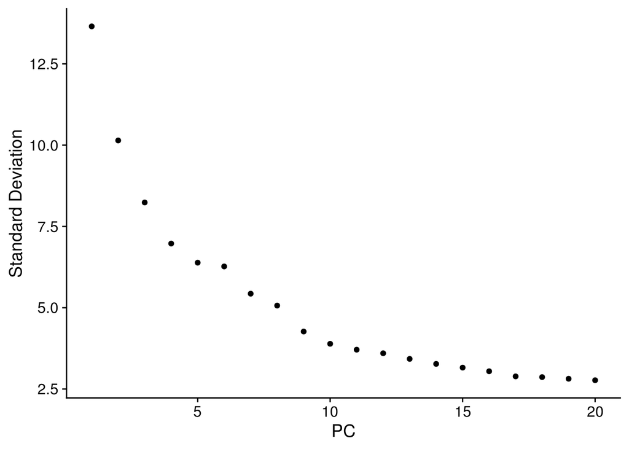

```r
pancreas <- RunPCA(pancreas, npcs =50,verbose=FALSE,features=rownames(pancreas))
ElbowPlot(pancreas,reduction = "pca")
```

```r
pancreas <- RunUMAP(pancreas, reduction = "pca", dims = 1:20, reduction.name = "umap",  reduction.key = "umap_")
```

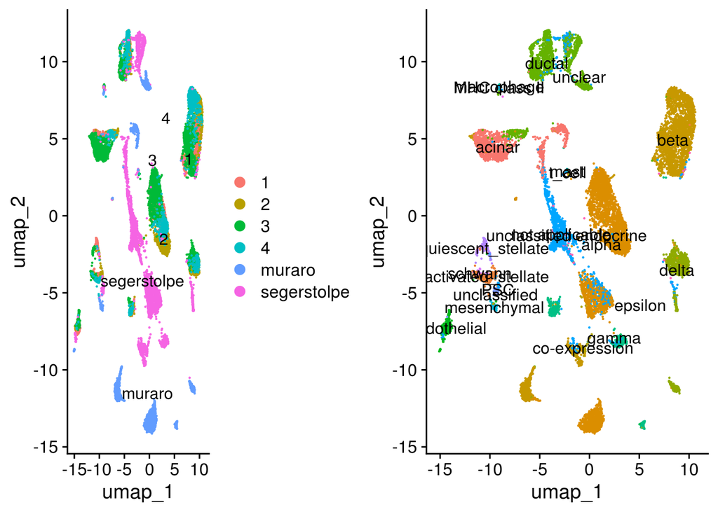

```r
p1 <- DimPlot(pancreas, reduction = 'umap', group.by = 'batch',label=1)
p2 <- DimPlot(pancreas, reduction = 'umap', group.by = 'celltype',label=1)+NoLegend()
plot_grid(p1,p2)
```

As we could see, even after preprocessing step, these datasets still exist strong batch effects. ICAnet aim to identify the shared gene co-expression pattern across different batches, therefore could be applied to correct batch effects. We first decompose each batch of scRNA-seq dataset through ICA

```r
ica.pancreas <- ICAcomputing(pancreas, ICA.type="JADE",two.stage = FALSE,global.mode=FALSE,center=FALSE,scale=TRUE)
```

```
## [1] "batch 1 Indepdent Component Analysis"
## [1] "emmm...scaling..."
```

```
## [1] "Done scaling"
## [1] "Using RMT to estimate number of module"
```

```
## [1] "RMT estimate 19 expression programm"
## [1] "batch 2 Indepdent Component Analysis"
## [1] "emmm...scaling..."
```

```
## [1] "Done scaling"
## [1] "Using RMT to estimate number of module"
## [1] "RMT estimate 18 expression programm"
## [1] "batch 3 Indepdent Component Analysis"
## [1] "emmm...scaling..."
```

```
## [1] "Done scaling"
## [1] "Using RMT to estimate number of module"
## [1] "RMT estimate 22 expression programm"
## [1] "batch 4 Indepdent Component Analysis"
## [1] "emmm...scaling..."
```

```
## [1] "Done scaling"
## [1] "Using RMT to estimate number of module"
## [1] "RMT estimate 15 expression programm"
## [1] "batch 5 Indepdent Component Analysis"
## [1] "emmm...scaling..."
```

```
## [1] "Done scaling"
## [1] "Using RMT to estimate number of module"
## [1] "RMT estimate 21 expression programm"
## [1] "batch 6 Indepdent Component Analysis"
## [1] "emmm...scaling..."
```

```
## [1] "Done scaling"
## [1] "Using RMT to estimate number of module"
## [1] "RMT estimate 21 expression programm"
```

```r
ica.filter <- CrossBatchGrouping(ica.pancreas$ica.pooling,cor="spearman",Unique.Preservation=FALSE)
```

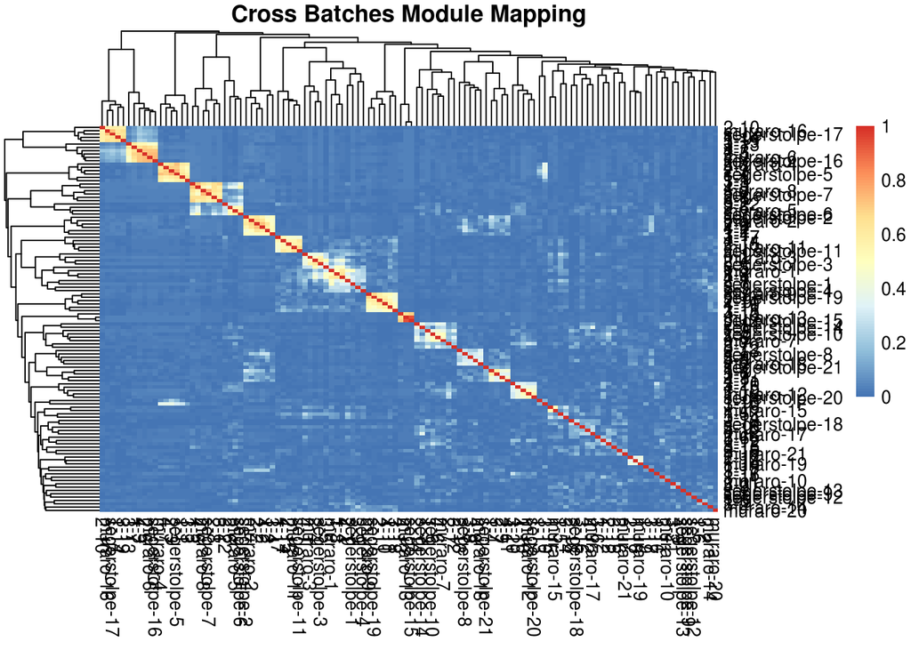

```
## Identify26 patterns
```

**Important parameters are as follows**:

- *Unique.Preservation* this boolean variable used to determine whether to select the cluster that more than 1 component. if this parameter is FALSE, then the clusters which have only one components are filtered.

### Stage III: Running ICAnet to perform batch effect correction

Before running ICAnet, To get the PPI network, the user could use *getPPI_Strings* functions provided by RSCORE packages

```r
library(RSCORE)
hs_network_matrix <- getPPI_String(pancreas,species = 9606)
```

Then, we run ICAnet to convert gene expression matrix into module activity matrix. Here I gonna use non-scale matrix to evaluate module activity.

```r
pancreas <- RunICAnet(pancreas,ica.filter$ica.filter, PPI.net = hs_network_matrix, W.top=2,aucMaxRank = 300,ModuleSignificance=FALSE,scale=FALSE)
```

```
## [1] 2043
## [1] "num:553"
```

```
## Quantiles for the number of genes detected by cell:
## (Non-detected genes are shuffled at the end of the ranking. Keep it in mind when choosing the threshold for calculating the AUC).
```

```
##     min      1%      5%     10%     50%    100%
##    1.00   39.08  122.00  164.00  344.00 1919.00
```

```
## Using 6 cores.
```

```
## Using 6 cores.
```

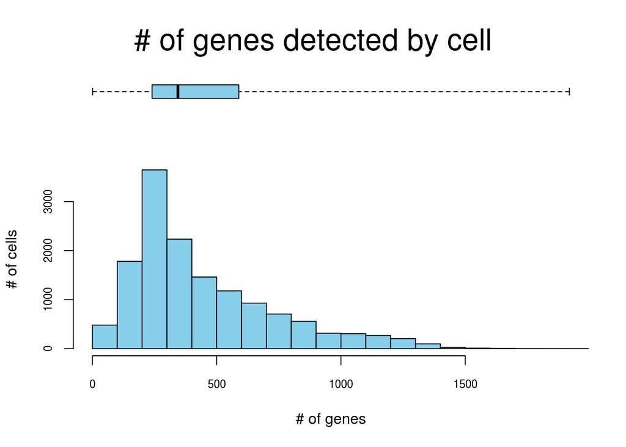

To perform dimensional reductions, here we provided a SVD-based feature reduction methods which could be used to improve batch mixing.

```r
pancreas <- RunModuleSVD(pancreas,nu=30,power=0.2)
```

**Important parameters are as follows**:

We could test different *power* setting to see how this parameter influence the batch mixing

```r
pancreas <- RunModuleSVD(pancreas,nu=30,power=0.1)
pancreas <- RunUMAP(pancreas, reduction = "Module_SVD", dims = 1:20, reduction.name = "umap_power_0.1",  reduction.key = "umap_",verbose=FALSE)
pancreas <- RunModuleSVD(pancreas,nu=30,power=0.2)
pancreas <- RunUMAP(pancreas, reduction = "Module_SVD", dims = 1:20, reduction.name = "umap_power_0.2",  reduction.key = "umap_",verbose=FALSE)
pancreas <- RunModuleSVD(pancreas,nu=30,power=0.35)
pancreas <- RunUMAP(pancreas, reduction = "Module_SVD", dims = 1:20, reduction.name = "umap_power_0.35",  reduction.key = "umap_",verbose=FALSE)
pancreas <- RunModuleSVD(pancreas,nu=30,power=0.5)
pancreas <- RunUMAP(pancreas, reduction = "Module_SVD", dims = 1:20, reduction.name = "umap_power_0.5",  reduction.key = "umap_",verbose=FALSE)
```

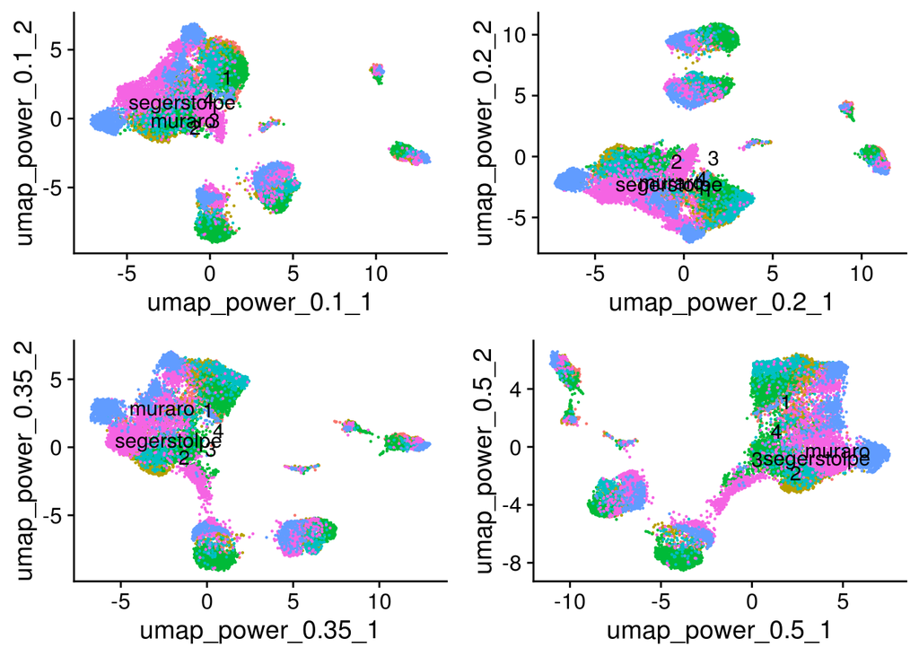

```r
p1 <- DimPlot(pancreas, reduction = 'umap_power_0.1', group.by = 'batch',label=1)+NoLegend()
p2 <- DimPlot(pancreas, reduction = 'umap_power_0.2', group.by = 'batch',label=1)+NoLegend()
p3 <- DimPlot(pancreas, reduction = 'umap_power_0.35', group.by = 'batch',label=1)+NoLegend()
p4 <- DimPlot(pancreas, reduction = 'umap_power_0.5', group.by = 'batch',label=1)+NoLegend()
plot_grid(p1,p2,p3,p4,nrow=2,ncol=2)
```

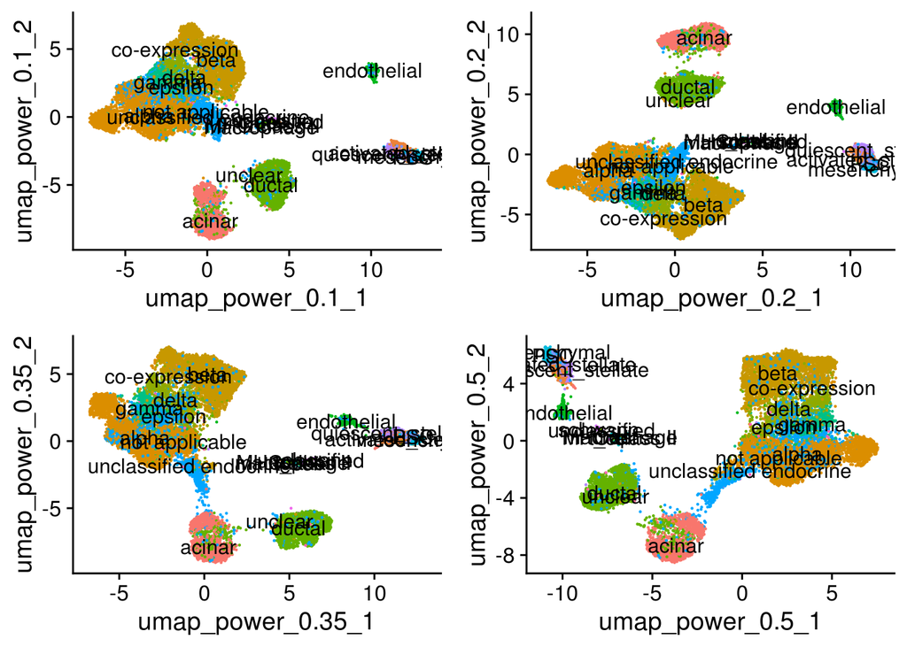

```r
p1 <- DimPlot(pancreas, reduction = 'umap_power_0.1', group.by = 'celltype',label=1)+NoLegend()
p2 <- DimPlot(pancreas, reduction = 'umap_power_0.2', group.by = 'celltype',label=1)+NoLegend()
p3 <- DimPlot(pancreas, reduction = 'umap_power_0.35', group.by = 'celltype',label=1)+NoLegend()
p4 <- DimPlot(pancreas, reduction = 'umap_power_0.5', group.by = 'celltype',label=1)+NoLegend()
plot_grid(p1,p2,p3,p4,nrow=2,ncol=2)
```

We could found that with the increasing of the *power*, the batch mixing is also improved, while it also could influence the cell type identification (which means the cells from some cell types are no longer group together) After running ICAnet, we could find that the most cells are largely grouped according to their cell identity. To further improve batch effect correction, we could scale gene expression matrix of each batch to further improve integrations. It has been validated by recently research that scaling could improve batch correction[1].

```r
DefaultAssay(pancreas) <- "Consensus.RNA"
pancreas <- RunICAnet(pancreas,ica.filter$ica.filter, species=9606, W.top=2,aucMaxRank = 300,scale=TRUE)
```

```
##
## Done Batch 1
```

```
##
## Done Batch 2
```

```
##
## Done Batch 3
```

```
##
## Done Batch 4
```

```
##
## Done Batch muraro
```

```
##
## Done Batch segerstolpe
```

```
## [1] 2043
## [1] 2043
## [1] "num:553"
```

```
## Quantiles for the number of genes detected by cell:
## (Non-detected genes are shuffled at the end of the ranking. Keep it in mind when choosing the threshold for calculating the AUC).
```

```
##  min   1%   5%  10%  50% 100%
##    1   38  114  155  317 1422
```

```
## Using 6 cores.
```

```
## Using 6 cores.
```

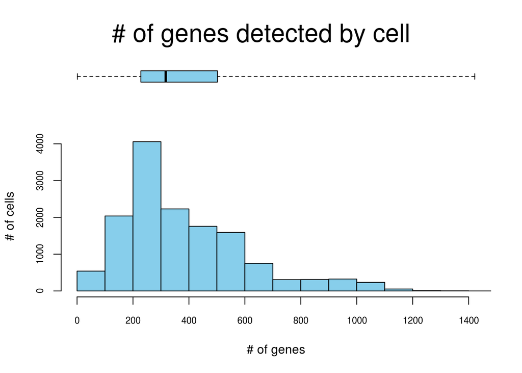

```r
pancreas <- RunModuleSVD(pancreas,nu=30,power=0.2)
pancreas <- RunUMAP(pancreas, reduction = "Module_SVD", dims = 1:20, reduction.name = "umap",  reduction.key = "umap_")
```

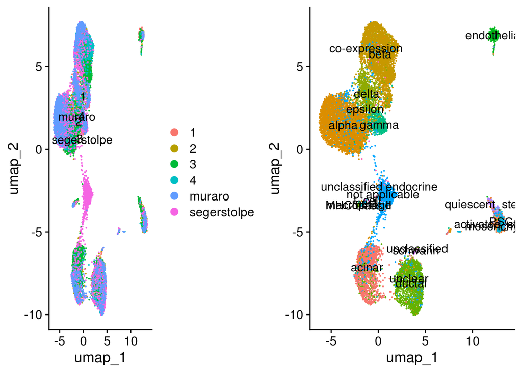

```r
p1 <- DimPlot(pancreas, reduction = 'umap', group.by = 'celltype',label=1)+NoLegend()
p2 <- DimPlot(pancreas, reduction = 'umap', group.by = 'batch',label=1)
plot_grid(p2,p1)
```

### Stage IV: Visualize statistical significance module(sub-network) activity pattern and network structure.

ICAnet also could visualize module statistical significance through compare its conditional number of gene members’ expression matrix with null(emperical) distribution generated from randomized module’s. Firstly, we need to select cell type specific module:

```r
pancreas@active.ident <- as.factor(pancreas$celltype)
modules <- FindMarkerModule(pancreas, identity="beta")
head(modules)
```

|  | myAUC | avg_diff | power | pct.1 | pct.2 | Module_significance |
| --- | --- | --- | --- | --- | --- | --- |
| ICAnet-17-2-11 | 0.955 | 0.2554782 | 0.910 | 0.993 | 0.577 | 0 |
| ICAnet-17-38-9 | 0.943 | 0.2349114 | 0.886 | 0.987 | 0.524 | 0 |
| ICAnet-22-23-5 | 0.922 | 0.2986747 | 0.844 | 0.955 | 0.344 | 0 |
| ICAnet-22-7-6 | 0.918 | 0.2509845 | 0.836 | 0.971 | 0.535 | 0 |
| ICAnet-5-8-5 | 0.916 | 0.2373001 | 0.832 | 0.977 | 0.629 | 0 |
| ICAnet-22-39-11 | 0.909 | 0.1708048 | 0.818 | 0.990 | 0.660 | 0 |

**Important parameters are as follows**: * *identity* character values to be used to specific the cell type ID * *MQC* boolean variable, used to define whether perform module quality control (filter the module which its pvalue > threshold) * *pvalue* interger value used to define the significant modules.default value is 0.05

**Additional Informations** * *module barcode* each module will be assign a “module barcode” to indicate their specific informations, encoded as the “ICAnet-from x th component-x th module-the number of gene in the module”

```r
library(networkD3)
```

```r
plot_module(gene_sets = pancreas@misc$IcaNet_geneSets[['ICAnet-17-2-11']],network=hs_network_matrix,nodeSize="ica.score",ica.score = abs(ica.filter$ica.filter[,17]),size_scale = 1.5)
```

[interactive chart not shown]

In this subnetwork, we could found that IAPP has the highest degree and ica.score, IAPP encoded islet amyloid polypeptide hormones, this hormone is released from pancreatic beta cell following food intake to regulate blood glucose levels.

Further, we could visualize the module activity pattern on UMAP plot as shown below

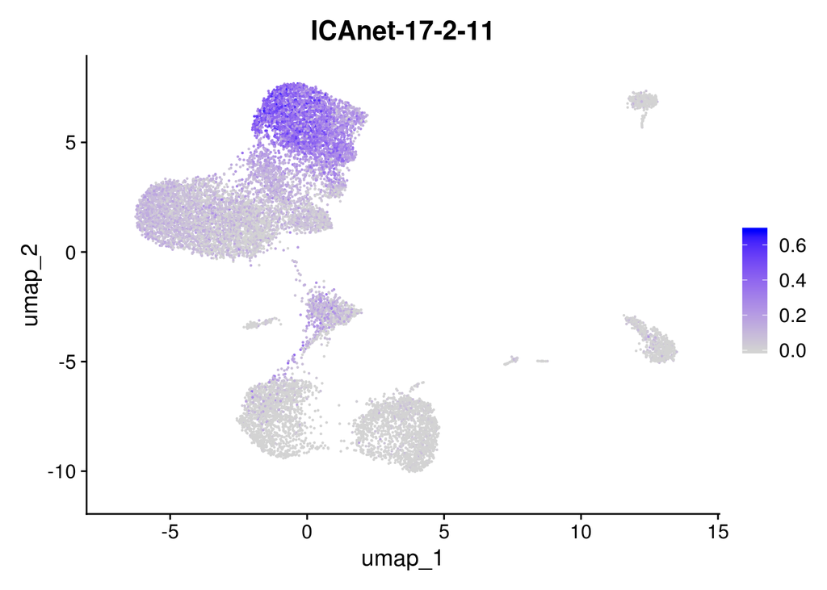

```r
FeaturePlot(pancreas,"ICAnet-17-2-11", reduction="umap")
```

### Reference

[1] Luecken M D, Buttner M, Chaichoompu K, et al. Benchmarking atlas-level data integration in single-cell genomics[J]. BioRxiv, 2020.